# Box-Jenkins flow

`r`r library(tidyverse) library(forecast) library(tseries)

`r`r daily_data = read_csv(‘input/day.csv’)

`r`r daily_data

```
# A tibble: 731 x 16
   instant dteday     season    yr  mnth holiday weekday workingday weathersit  temp atemp   hum
     <int> <date>      <int> <int> <int>   <int>   <int>      <int>      <int> <dbl> <dbl> <dbl>
 1       1 2011-01-01      1     0     1       0       6          0          2 0.344 0.364 0.806
 2       2 2011-01-02      1     0     1       0       0          0          2 0.363 0.354 0.696
 3       3 2011-01-03      1     0     1       0       1          1          1 0.196 0.189 0.437
 4       4 2011-01-04      1     0     1       0       2          1          1 0.200 0.212 0.590
 5       5 2011-01-05      1     0     1       0       3          1          1 0.227 0.229 0.437
 6       6 2011-01-06      1     0     1       0       4          1          1 0.204 0.233 0.518
 7       7 2011-01-07      1     0     1       0       5          1          2 0.197 0.209 0.499
 8       8 2011-01-08      1     0     1       0       6          0          2 0.165 0.162 0.536
 9       9 2011-01-09      1     0     1       0       0          0          1 0.138 0.116 0.434
10      10 2011-01-10      1     0     1       0       1          1          1 0.151 0.151 0.483
# ... with 721 more rows, and 4 more variables: windspeed <dbl>, casual <int>, registered <int>,
#   cnt <int>
```

`r`r ggplot(daily_data,aes(x=dteday,y=cnt))+ geom_line()+ scale_x_date(‘month’)+ ylab(Bike Checkouts)

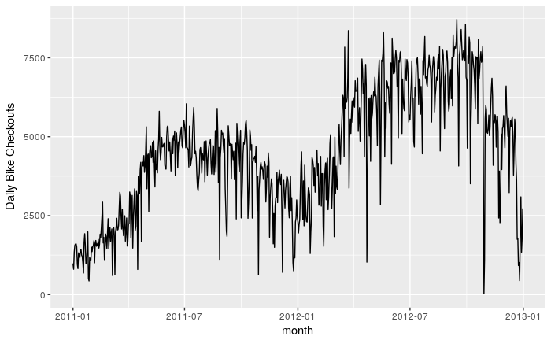

- 冬はバイクレンタル数が減り，夏は増える．
- 全体として，レンタル数は伸びている.

`r`r count_ts <- ts(daily_data[,c(‘cnt’)]) head(count_ts)

```
Time Series:
Start = 1
End = 6
Frequency = 1
      cnt
[1,]  985
[2,]  801
[3,] 1349
[4,] 1562
[5,] 1600
[6,] 1606
```

`r`r daily_data$clean_cnt <- tsclean(count_ts)

`r`r ggplot(data=daily_data,aes(x=dteday,y=clean_cnt))+ geom_line()+ scale_x_date(‘month’)+ ylab(Bicycle Count)

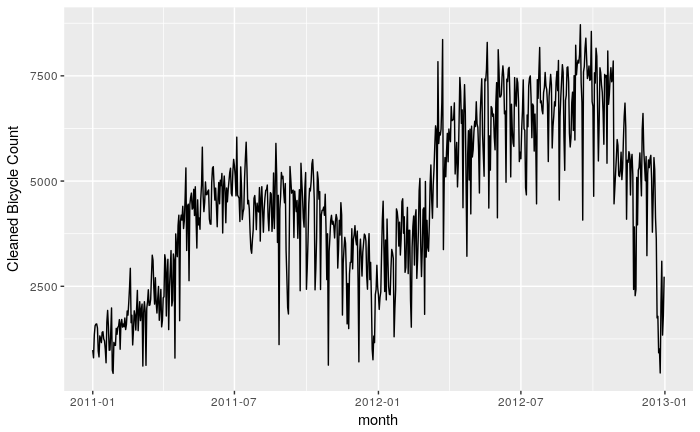

## Moving Averageによる平滑化

`r`r daily_data$cnt_ma <- forecast::ma(daily_data$clean_cnt,order=7) daily_data$cnt_ma30 <- forecast::ma(daily_data$clean_cnt,order=30)

`r`r ggplot(data=daily_data,aes(x=dteday))+ geom_line(aes(y=clean_cnt,color=‘Counts’))+ geom_line(aes(y=cnt_ma,color=‘Weekly Moving Average’))+ geom_line(aes(y=cnt_ma30,color=‘Monthly Moving Average’))+ ylab(Count)

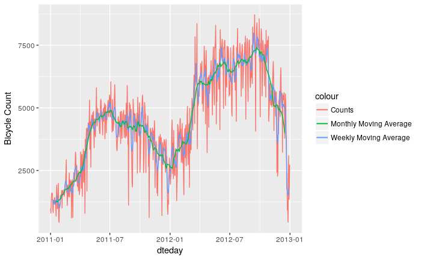

## Decompose Data

- Seasonal component
- Trend component
- Cycle component

seasonal componentはカレンダーのサイクルに関連した変動．例えば，夏にはバイクに乗る人が増え，冬には減るなど．

Trend componentは全体的なパターン．次第にレンタル数は増えているなど．

Cycle componentはseasonalでない増加減少のパターン．trendとグルーピングされる．

$$Y = S_t\times T_t \times E_t$$

$$Y = S_t+T_t + E_t$$

`r`r count_ma <- ts(na.omit(daily_data$cnt_ma),frequency = 30) head(count_ma)

```
Time Series:
Start = c(1, 1)
End = c(1, 6)
Frequency = 30
[1] 1344.714 1341.000 1344.000 1340.000 1297.286 1234.714
```

`r`r decomp <- stl(count_ma,s.window = ) deseasonal_cnt <- seasadj(decomp) plot(decomp)

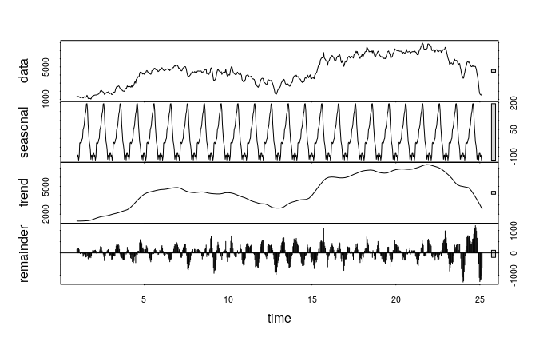

## Stationarity

`r`r adf.test(count_ma, alternative = )

```
p-value greater than printed p-value

    Augmented Dickey-Fuller Test

data:  count_ma
Dickey-Fuller = -0.2557, Lag order = 8, p-value = 0.99
alternative hypothesis: stationary
```

`r`r Acf(count_ma)

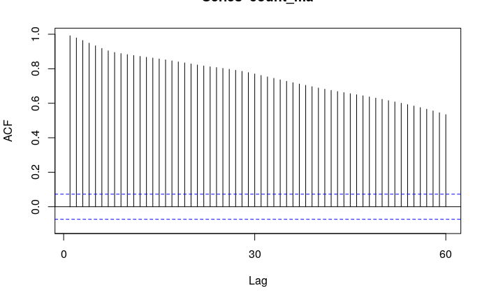

`r`r Pacf(count_ma)

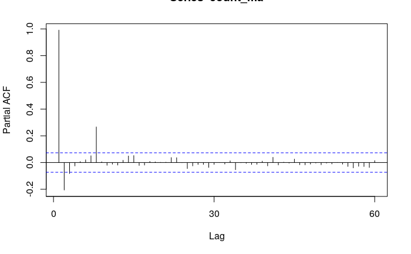

`r`r count_d1 <- diff(deseasonal_cnt,differences = 1) plot(count_d1)

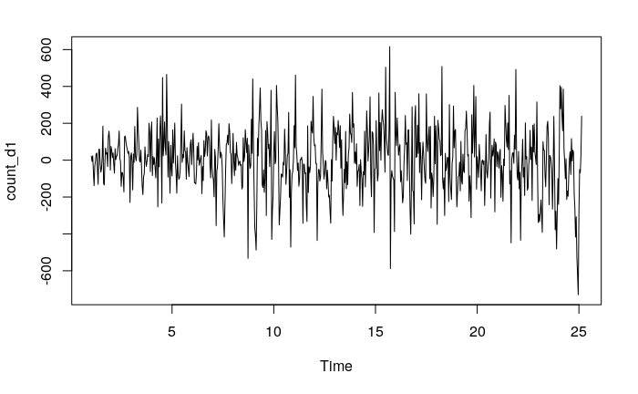

`r`r adf.test(count_d1,alternative = ‘stationary’)

```
p-value smaller than printed p-value

    Augmented Dickey-Fuller Test

data:  count_d1
Dickey-Fuller = -9.9255, Lag order = 8, p-value = 0.01
alternative hypothesis: stationary
```

`r`r Acf(count_d1, main=‘ACF for Differenced Series’)

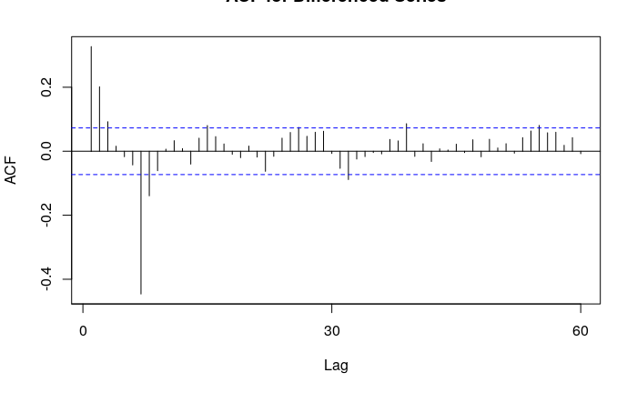

`r`r Pacf(count_d1, main=‘PACF for Differenced Series’)

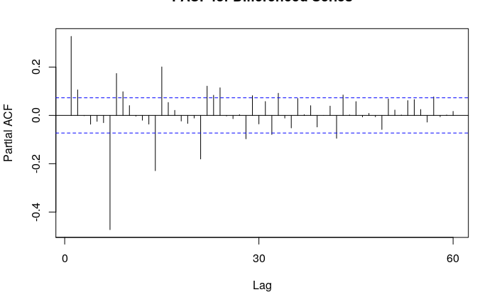

`r`r auto.arima(deseasonal_cnt, seasonal=FALSE)

```
Series: deseasonal_cnt
ARIMA(1,1,1)

Coefficients:
         ar1      ma1
      0.5510  -0.2496
s.e.  0.0751   0.0849

sigma^2 estimated as 26180:  log likelihood=-4708.91
AIC=9423.82   AICc=9423.85   BIC=9437.57
```

`r`r fit<-auto.arima(deseasonal_cnt, seasonal=FALSE) tsdisplay(residuals(fit), lag.max=45, main=‘(1,1,1) Model Residuals’)

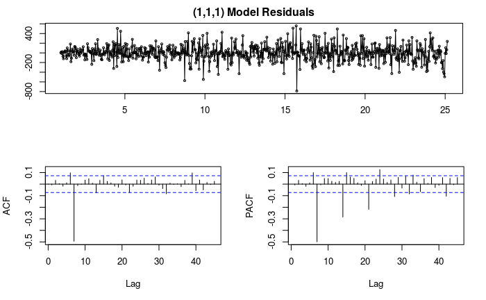